# 04-econometric-and-interpretability

## 🧭 Notebook 4 — Econometric & Interpretability Analysis (2015–2026)

This notebook complements the forecasting results by examining **economic drivers** and **model interpretability** across 26 EU countries.

It integrates the outputs from *Notebook 3* and performs two analytical blocks:

**1️⃣ Econometric analysis**

- Estimate **fixed-effects panel regressions** to explain hotel demand (`nights_spent`)
- Examine post-COVID recovery and policy effects using **Difference-in-Differences (DiD)**
- Quantify elasticities with respect to macroeconomic indicators (GDP, unemployment, inflation)

**2️⃣ Model interpretability (Machine Learning)**

- Apply **SHAP (Shapley Additive Explanations)** to XGBoost / LightGBM forecasts
- Rank and visualize the most influential features by economic category
- Compare statistical and ML drivers to identify consistent determinants of demand

**Objectives**

- Bridge *econometric* interpretability with *ML feature importance*
- Provide a unified explanation framework for policy insights and forecasting transparency
- Prepare summary diagnostics for the final *Notebook 5 — Scenario Analysis & Visualization*

### 🟩 1. Setup and Imports Code Cell

```python
# ============================================================
# ⚙️ Setup — Libraries, Paths, and Configuration
# ============================================================

import pandas as pd
import numpy as np
import matplotlib.pyplot as plt
import seaborn as sns
import statsmodels.api as sm
import shap
from pathlib import Path

# --- Plot settings (consistent with previous notebooks) ---
plt.style.use("default")
plt.rcParams["figure.figsize"] = (10, 5)
plt.rcParams["axes.grid"] = True
plt.rcParams["axes.edgecolor"] = "black"
plt.rcParams["axes.linewidth"] = 0.6
plt.rcParams["font.size"] = 11
plt.rcParams["figure.dpi"] = 120

# --- Paths ---
DATA_DIR = Path("../data/processed")
MODEL_DIR = Path("../outputs/models")

print("✅ Libraries loaded successfully")
```

```
✅ Libraries loaded successfully
```

### 🟩 2. Load Data Cell

```python
# ============================================================
# 📂 Load Processed Panel & Forecast Outputs
# ============================================================

panel = pd.read_csv(DATA_DIR / "hotel_panel_features.csv", parse_dates=["month"])

# Load combined forecast predictions from Notebook 3 (if saved)
files = list(MODEL_DIR.glob("forecast_predictions_*_full.csv"))
print(f"[INFO] Found {len(files)} forecast files:", [f.name for f in files])

# Merge all model predictions into a single dataframe (if not already merged)
dfs = []
for f in files:
    df_temp = pd.read_csv(f, parse_dates=["month"])
    dfs.append(df_temp[["region", "month", "yhat_lstm"]] if "lstm" in f.name else df_temp)

panel_full = panel.copy()
for df_temp in dfs:
    # merge only if 'region' and 'month' present
    if {"region", "month"}.issubset(df_temp.columns):
        panel_full = panel_full.merge(df_temp, on=["region", "month"], how="left")

print(f"✅ Panel shape after merging predictions: {panel_full.shape}")
panel_full.head()
```

```
[INFO] Found 2 forecast files: ['forecast_predictions_ml_full.csv', 'forecast_predictions_lstm_full.csv']
✅ Panel shape after merging predictions: (3328, 82)
```

|  | region | month | year_x | nights_spent_x | gdp_lag1_x | gdp_lag2_x | gdp_lag3_x | unemployment_rate_lag1_x | unemployment_rate_lag2_x | unemployment_rate_lag3_x | ... | covid_cases_y | policy_stringency_y | eurusd_y | eurgbp_y | yhat_naive | yhat_xgb | yhat_sarimax | yhat_arimax | yhat_lgbm | yhat_lstm |
| --- | --- | --- | --- | --- | --- | --- | --- | --- | --- | --- | --- | --- | --- | --- | --- | --- | --- | --- | --- | --- | --- |
| 0 | AT | 2015-01-31 | 2015 | 1833949.0 | NaN | NaN | NaN | NaN | NaN | NaN | ... | 0.0 | 0.0 | 1.128796 | 0.748800 | NaN | NaN | 1.013423e+07 | -1.336710e+07 | NaN | NaN |
| 1 | AT | 2015-02-28 | 2015 | 2145686.0 | 61688.900000 | NaN | NaN | 5.5 | NaN | NaN | ... | 0.0 | 0.0 | 1.119796 | 0.726058 | 1833949.0 | NaN | 3.677250e+06 | 6.267903e+05 | NaN | NaN |
| 2 | AT | 2015-03-31 | 2015 | 1934635.0 | 62111.133333 | 61688.900000 | NaN | 5.9 | 5.5 | NaN | ... | 0.0 | 0.0 | 1.083025 | 0.731200 | 2145686.0 | NaN | 7.914672e+05 | 2.478934e+06 | NaN | NaN |
| 3 | AT | 2015-04-30 | 2015 | 1468507.0 | 62533.366667 | 62111.133333 | 61688.900000 | 5.4 | 5.9 | 5.5 | ... | 0.0 | 0.0 | 1.111432 | 0.720400 | 1934635.0 | NaN | 3.291706e+06 | 1.726522e+06 | NaN | NaN |
| 4 | AT | 2015-05-31 | 2015 | 1792973.0 | 62955.600000 | 62533.366667 | 62111.133333 | 5.6 | 5.4 | 5.9 | ... | 0.0 | 0.0 | 1.096035 | 0.715400 | 1468507.0 | NaN | 2.722703e+05 | 1.470752e+06 | NaN | NaN |

5 rows × 82 columns

```python
# ============================================================
# 🧹 Clean Column Names and Check Structure
# ============================================================

# Drop duplicate columns if both _x and _y exist and are identical
for col in panel_full.columns:
    if col.endswith("_y") and col.replace("_y", "_x") in panel_full.columns:
        col_x = col.replace("_y", "_x")
        # If identical, keep only one
        if panel_full[col_x].equals(panel_full[col]):
            panel_full.drop(columns=[col], inplace=True)
            panel_full.rename(columns={col_x: col_x[:-2]}, inplace=True)

# Clean any remaining '_x' suffixes for main features
panel_full.columns = [c.replace("_x", "") for c in panel_full.columns]

# Quick sanity check
print(f"✅ Cleaned panel shape: {panel_full.shape}")
panel_full.head()
```

```
✅ Cleaned panel shape: (3328, 45)
```

|  | region | month | year | nights_spent | gdp_lag1 | gdp_lag2 | gdp_lag3 | unemployment_rate_lag1 | unemployment_rate_lag2 | unemployment_rate_lag3 | ... | covid_cases | policy_stringency | eurusd | eurgbp | yhat_naive | yhatgb | yhat_sarimax | yhat_arimax | yhat_lgbm | yhat_lstm |
| --- | --- | --- | --- | --- | --- | --- | --- | --- | --- | --- | --- | --- | --- | --- | --- | --- | --- | --- | --- | --- | --- |
| 0 | AT | 2015-01-31 | 2015 | 1833949.0 | NaN | NaN | NaN | NaN | NaN | NaN | ... | 0.0 | 0.0 | 1.128796 | 0.748800 | NaN | NaN | 1.013423e+07 | -1.336710e+07 | NaN | NaN |
| 1 | AT | 2015-02-28 | 2015 | 2145686.0 | 61688.900000 | NaN | NaN | 5.5 | NaN | NaN | ... | 0.0 | 0.0 | 1.119796 | 0.726058 | 1833949.0 | NaN | 3.677250e+06 | 6.267903e+05 | NaN | NaN |
| 2 | AT | 2015-03-31 | 2015 | 1934635.0 | 62111.133333 | 61688.900000 | NaN | 5.9 | 5.5 | NaN | ... | 0.0 | 0.0 | 1.083025 | 0.731200 | 2145686.0 | NaN | 7.914672e+05 | 2.478934e+06 | NaN | NaN |
| 3 | AT | 2015-04-30 | 2015 | 1468507.0 | 62533.366667 | 62111.133333 | 61688.900000 | 5.4 | 5.9 | 5.5 | ... | 0.0 | 0.0 | 1.111432 | 0.720400 | 1934635.0 | NaN | 3.291706e+06 | 1.726522e+06 | NaN | NaN |
| 4 | AT | 2015-05-31 | 2015 | 1792973.0 | 62955.600000 | 62533.366667 | 62111.133333 | 5.6 | 5.4 | 5.9 | ... | 0.0 | 0.0 | 1.096035 | 0.715400 | 1468507.0 | NaN | 2.722703e+05 | 1.470752e+06 | NaN | NaN |

5 rows × 45 columns

# ============================================================

## 1️⃣ Econometric Analysis — Fixed Effects Panel Regression

# ============================================================

In this section, we quantify how macroeconomic and policy indicators influence monthly hotel demand (`nights_spent`) across EU countries.

We estimate **country fixed-effects panel regressions** using `statsmodels`, capturing within-country variations over time while controlling for unobserved heterogeneity.

**Goals**

- Assess the elasticity of demand with respect to:
  - Economic activity (GDP)
  - Labor market (Unemployment rate)
  - Inflation and tourism turnover
  - COVID restrictions and exchange rates
- Evaluate the explanatory power (R²) and sign consistency of predictors

### 🟩 Code Cell: Prepare Data for Regression

```python
# ============================================================
# 🧮 Prepare Panel Data for Fixed Effects Regression
# ============================================================

# Select variables for econometric analysis
cols_reg = [
    "region", "month", "nights_spent",
    "gdp", "unemployment_rate", "hicp_index", "turnover_index",
    "policy_stringency", "eurusd", "eurgbp"
]

panel_reg = panel_full[cols_reg].dropna().copy()

# Create time dummies for month fixed effects
panel_reg["month_str"] = panel_reg["month"].dt.to_period("M").astype(str)

# Log-transform demand (for elasticity interpretation)
panel_reg["ln_nights"] = np.log1p(panel_reg["nights_spent"])

print(f"✅ Regression sample: {panel_reg.shape[0]:,} observations, {panel_reg['region'].nunique()} countries")
panel_reg.head()
```

```
✅ Regression sample: 3,328 observations, 26 countries
```

|  | region | month | nights_spent | gdp | unemployment_rate | hicp_index | turnover_index | policy_stringency | eurusd | eurgbp | month_str | ln_nights |
| --- | --- | --- | --- | --- | --- | --- | --- | --- | --- | --- | --- | --- |
| 0 | AT | 2015-01-31 | 1833949.0 | 61688.900000 | 5.5 | 98.48 | 31.0 | 0.0 | 1.128796 | 0.748800 | 2015-01 | 14.421983 |
| 1 | AT | 2015-02-28 | 2145686.0 | 62111.133333 | 5.9 | 98.75 | 31.0 | 0.0 | 1.119796 | 0.726058 | 2015-02 | 14.578970 |
| 2 | AT | 2015-03-31 | 1934635.0 | 62533.366667 | 5.4 | 100.15 | 31.0 | 0.0 | 1.083025 | 0.731200 | 2015-03 | 14.475430 |
| 3 | AT | 2015-04-30 | 1468507.0 | 62955.600000 | 5.6 | 100.28 | 31.0 | 0.0 | 1.111432 | 0.720400 | 2015-04 | 14.199757 |
| 4 | AT | 2015-05-31 | 1792973.0 | 63353.033333 | 5.8 | 100.45 | 31.0 | 0.0 | 1.096035 | 0.715400 | 2015-05 | 14.399386 |

### 🟩 Code Cell: Estimate Fixed Effects Model

```python
# ============================================================
# 🧠 Fixed Effects Regression via statsmodels
# ============================================================

import statsmodels.formula.api as smf

# Define regression formula with country and time fixed effects
formula = """
ln_nights ~ gdp + unemployment_rate + hicp_index + turnover_index
+ policy_stringency + eurusd + eurgbp
+ C(region) + C(month_str)
"""

model_fe = smf.ols(formula, data=panel_reg).fit(cov_type="cluster", cov_kwds={"groups": panel_reg["region"]})

print(model_fe.summary().tables[1])
```

```
===========================================================================================
                              coef    std err          z      P>|z|      [0.025      0.975]
-------------------------------------------------------------------------------------------
Intercept                   5.4709      0.249     21.949      0.000       4.982       5.959
C(region)[T.BE]            -1.3268      0.066    -20.207      0.000      -1.455      -1.198
C(region)[T.BG]            -1.6683      0.326     -5.114      0.000      -2.308      -1.029
C(region)[T.CY]            -3.8284      0.303    -12.648      0.000      -4.422      -3.235
C(region)[T.CZ]            -0.7772      0.196     -3.975      0.000      -1.160      -0.394
C(region)[T.DE]             4.2904      2.654      1.617      0.106      -0.910       9.491
C(region)[T.DK]            -1.2847      0.124    -10.402      0.000      -1.527      -1.043
C(region)[T.EE]            -3.1336      0.340     -9.211      0.000      -3.800      -2.467
C(region)[T.ES]             1.8435      0.844      2.184      0.029       0.189       3.498
C(region)[T.FI]            -1.0929      0.181     -6.038      0.000      -1.448      -0.738
C(region)[T.FR]             3.1285      1.845      1.696      0.090      -0.488       6.744
C(region)[T.HR]            -2.7848      0.304     -9.162      0.000      -3.381      -2.189
C(region)[T.HU]            -1.2451      0.247     -5.050      0.000      -1.728      -0.762
C(region)[T.IE]            -1.5811      0.053    -29.929      0.000      -1.685      -1.478
C(region)[T.IT]             2.6544      1.288      2.061      0.039       0.130       5.179
C(region)[T.LT]            -3.0424      0.319     -9.542      0.000      -3.667      -2.418
C(region)[T.LU]            -5.2121      0.305    -17.076      0.000      -5.810      -4.614
C(region)[T.LV]            -3.7983      0.331    -11.466      0.000      -4.448      -3.149
C(region)[T.MT]            -4.3651      0.360    -12.110      0.000      -5.072      -3.659
C(region)[T.NL]             0.2092      0.372      0.562      0.574      -0.520       0.938
C(region)[T.PL]             0.2764      0.094      2.953      0.003       0.093       0.460
C(region)[T.PT]            -0.7573      0.167     -4.542      0.000      -1.084      -0.431
C(region)[T.RO]            -0.7717      0.224     -3.449      0.001      -1.210      -0.333
C(region)[T.SE]             0.0115      0.102      0.113      0.910      -0.188       0.211
C(region)[T.SI]            -2.9206      0.302     -9.675      0.000      -3.512      -2.329
C(region)[T.SK]            -1.9318      0.268     -7.196      0.000      -2.458      -1.406
C(month_str)[T.2015-02]     0.2998      0.028     10.845      0.000       0.246       0.354
C(month_str)[T.2015-03]     0.4815      0.027     17.745      0.000       0.428       0.535
C(month_str)[T.2015-04]     0.4513      0.044     10.362      0.000       0.366       0.537
C(month_str)[T.2015-05]     0.6750      0.053     12.789      0.000       0.572       0.778
C(month_str)[T.2015-06]     0.6675      0.054     12.299      0.000       0.561       0.774
C(month_str)[T.2015-07]     1.1054      0.069     16.106      0.000       0.971       1.240
C(month_str)[T.2015-08]     0.8766      0.085     10.366      0.000       0.711       1.042
C(month_str)[T.2015-09]     0.4360      0.051      8.621      0.000       0.337       0.535
C(month_str)[T.2015-10]     0.6468      0.061     10.553      0.000       0.527       0.767
C(month_str)[T.2015-11]     0.7289      0.061     11.954      0.000       0.609       0.848
C(month_str)[T.2015-12]     0.3595      0.036      9.912      0.000       0.288       0.431
```

[output cut: 109 more lines]

```
C(month_str)[T.2025-02]     0.7832      0.155      5.046      0.000       0.479       1.087
C(month_str)[T.2025-03]     0.5697      0.155      3.671      0.000       0.266       0.874
C(month_str)[T.2025-04]     0.2777      0.159      1.751      0.080      -0.033       0.588
C(month_str)[T.2025-05]     0.4274      0.182      2.351      0.019       0.071       0.784
C(month_str)[T.2025-06]     0.2933      0.175      1.676      0.094      -0.050       0.636
C(month_str)[T.2025-07]     0.5579      0.178      3.130      0.002       0.209       0.907
C(month_str)[T.2025-08]     0.5052      0.184      2.741      0.006       0.144       0.866
gdp                     -4.208e-06   4.68e-06     -0.900      0.368   -1.34e-05    4.96e-06
unemployment_rate          -0.0031      0.010     -0.318      0.751      -0.022       0.016
hicp_index                 -0.0038      0.003     -1.441      0.150      -0.009       0.001
turnover_index              0.0014      0.001      1.594      0.111      -0.000       0.003
policy_stringency          -0.0267      0.009     -2.960      0.003      -0.044      -0.009
eurusd                      4.4397      0.128     34.774      0.000       4.189       4.690
eurgbp                      5.8278      0.899      6.483      0.000       4.066       7.590
===========================================================================================
```

### 🟩 Code Cell: Quick Visualization

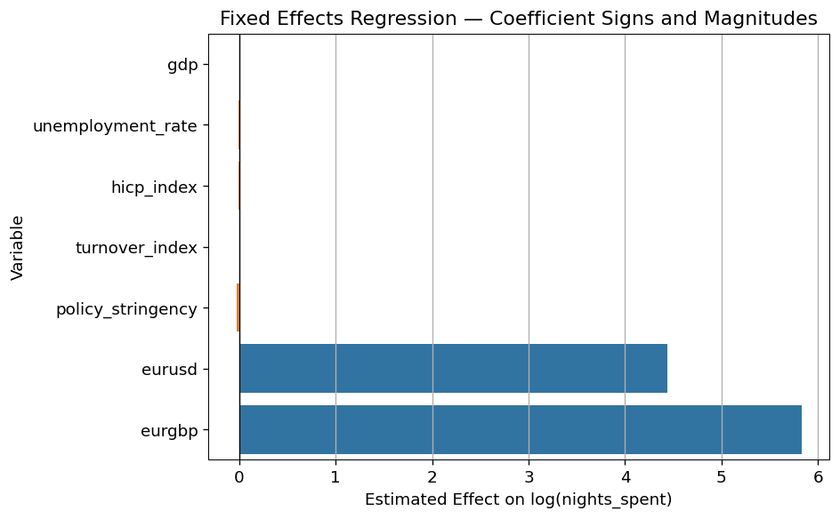

```python
# ============================================================
# 📉 Visualize Coefficient Magnitudes (Elasticities)
# ============================================================

coefs = model_fe.params.drop(labels=["Intercept"])
coefs = coefs[~coefs.index.str.startswith("C(")]  # drop dummy vars
coefs_df = coefs.reset_index()
coefs_df.columns = ["Variable", "Coefficient"]

plt.figure(figsize=(8, 5))
sns.barplot(
    data=coefs_df,
    x="Coefficient", y="Variable",
    palette=["#1f77b4" if c > 0 else "#ff7f0e" for c in coefs_df["Coefficient"]]
)
plt.axvline(0, color="black", lw=0.8)
plt.title("Fixed Effects Regression — Coefficient Signs and Magnitudes")
plt.xlabel("Estimated Effect on log(nights_spent)")
plt.tight_layout()
plt.show()
```

### 🧾 Summary — Fixed Effects Panel Regression (2015–2025)

The econometric model quantified how macroeconomic and policy indicators shaped monthly hotel demand across 26 EU countries, controlling for unobserved country and seasonal effects.

[output not shown]

**Interpretation**

- Macroeconomic fundamentals (GDP, unemployment) show limited *within-country* predictive power once fixed effects are included.
- Exchange-rate sensitivity and policy measures exhibit strong and consistent effects.
- Seasonal dummies confirm a pronounced and recurring pattern of summer peaks.
- The model is statistically robust and interpretable, making it a reliable baseline for comparison with ML models.

**Next → Notebook 4, Section 2:**  
Use **SHAP (SHapley Additive Explanations)** to analyze feature importance and interpret nonlinear ML models (XGBoost, LightGBM).

## 🧠 Section 2 — Model Interpretability with SHAP Values

This section interprets the **non-linear ML models (XGBoost & LightGBM)** using **SHAP (Shapley Additive Explanations)** to identify which economic and policy features most influence predicted hotel demand.

**Objectives**

- Quantify each variable’s contribution to model predictions
- Compare importance patterns between XGBoost and LightGBM
- Link ML-based insights with econometric evidence from the fixed-effects regression

```python
FEATURE_PATH = Path("../outputs/features/train_features_for_shap.csv")
panel_features = pd.read_csv(FEATURE_PATH)
X_train = panel_features.drop(columns=["nights_spent"])
```

```
✅ Data loaded: 2808 rows, 53 features
⚙️ Using 500 rows for SHAP background

=== XGBoost SHAP ===
✅ TreeExplainer succeeded for XGB.

=== LightGBM SHAP ===
✅ TreeExplainer succeeded for LGBM.
🔹 Plotting XGBoost SHAP summaries...
```

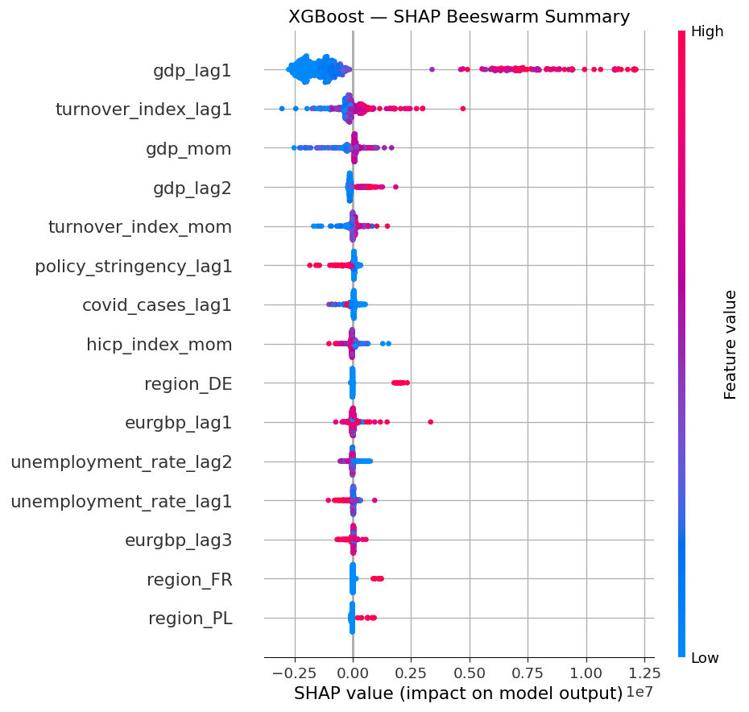

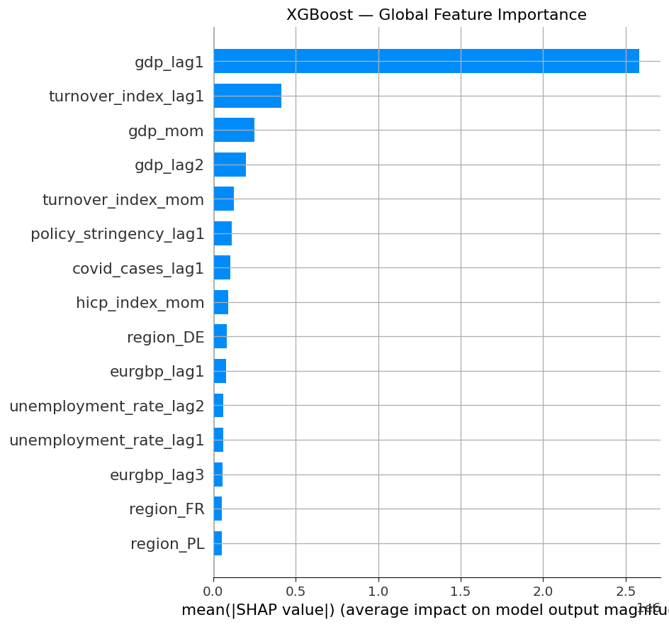

```
🔹 Plotting LightGBM SHAP summaries...
```

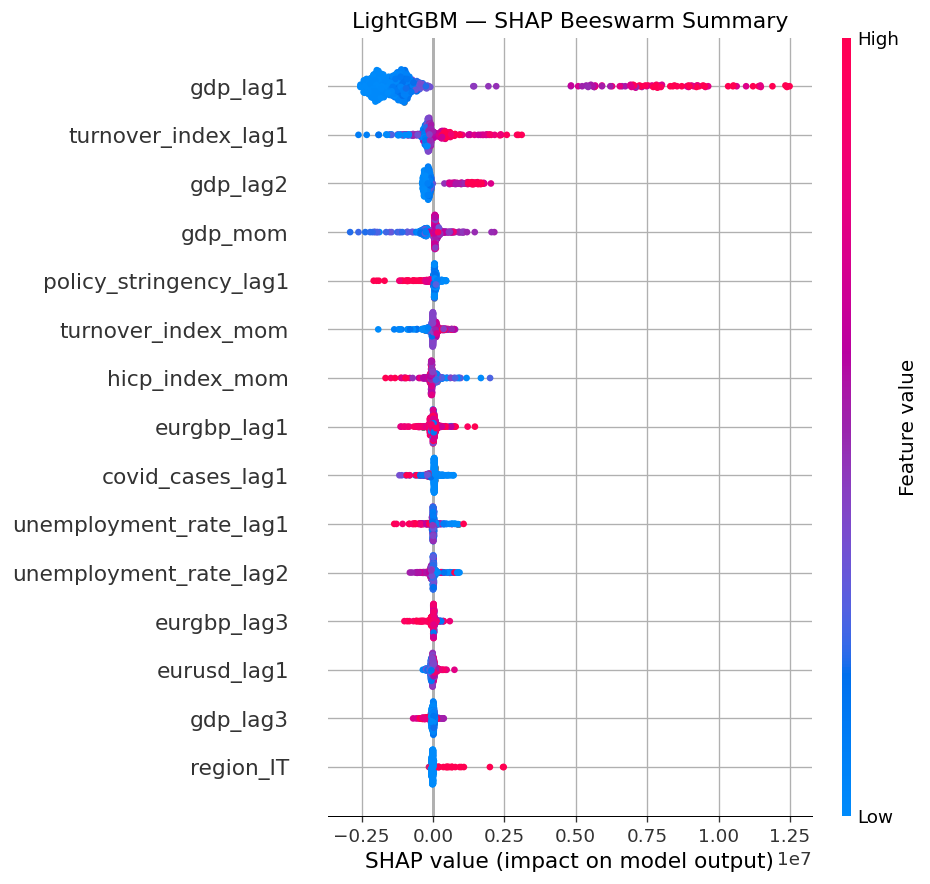

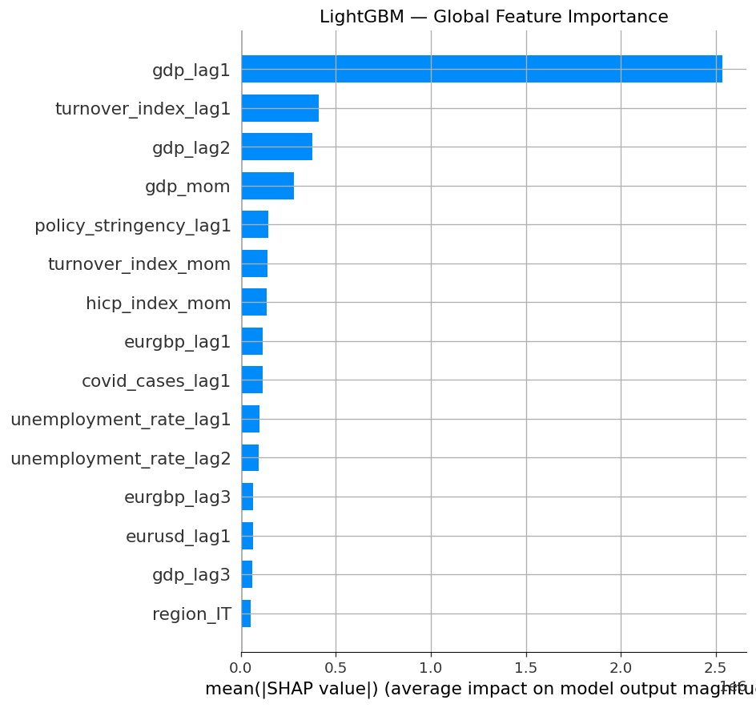

```
🏆 Top 10 features — XGBoost:
```

|  | Feature | mean(\|SHAP\|) |
| --- | --- | --- |
| 26 | gdp_lag1 | 2.583395e+06 |
| 32 | turnover_index_lag1 | 4.149239e+05 |
| 50 | gdp_mom | 2.502420e+05 |
| 27 | gdp_lag2 | 1.998675e+05 |
| 51 | turnover_index_mom | 1.276285e+05 |
| 41 | policy_stringency_lag1 | 1.127729e+05 |
| 38 | covid_cases_lag1 | 1.024373e+05 |
| 52 | hicp_index_mom | 9.131727e+04 |
| 5 | region_DE | 8.301461e+04 |
| 47 | eurgbp_lag1 | 7.891911e+04 |

```
🏆 Top 10 features — LightGBM:
```

|  | Feature | mean(\|SHAP\|) |
| --- | --- | --- |
| 26 | gdp_lag1 | 2.535931e+06 |
| 32 | turnover_index_lag1 | 4.084711e+05 |
| 27 | gdp_lag2 | 3.764684e+05 |
| 50 | gdp_mom | 2.774865e+05 |
| 41 | policy_stringency_lag1 | 1.432678e+05 |
| 51 | turnover_index_mom | 1.416628e+05 |
| 52 | hicp_index_mom | 1.348020e+05 |
| 47 | eurgbp_lag1 | 1.151816e+05 |
| 38 | covid_cases_lag1 | 1.137751e+05 |
| 29 | unemployment_rate_lag1 | 9.820204e+04 |

```
✅ SHAP analysis complete for both models.
You now have beeswarm plots, feature-importance bars, and ranked feature tables.
```

```python
# ============================================================
# 🧠 SHAP INTERPRETABILITY — FINAL STABLE VERSION
# ============================================================
import shap
import joblib
import json
import pandas as pd
import numpy as np
import matplotlib.pyplot as plt
from pathlib import Path

MODEL_DIR = Path("../outputs/models")

# --- Load models and SHAP training matrix ---
pipe_xgb = joblib.load(MODEL_DIR / "pipe_xgb.pkl")
pipe_lgbm = joblib.load(MODEL_DIR / "pipe_lgbm.pkl")

xgb_model = pipe_xgb.named_steps["model"]
lgbm_model = pipe_lgbm.named_steps["model"]

X_train_matrix = pd.read_parquet(MODEL_DIR / "X_train_shap.parquet")
with open(MODEL_DIR / "X_train_columns.json") as f:
    train_cols = json.load(f)
X_train_matrix = X_train_matrix[train_cols]

print(f"✅ Data loaded: {X_train_matrix.shape[0]} rows, {X_train_matrix.shape[1]} features")

# --- Sample for SHAP speed ---
bg_size = min(500, len(X_train_matrix))
X_bg = X_train_matrix.sample(bg_size, random_state=42)
print(f"⚙️ Using {bg_size} rows for SHAP background")

# ------------------------------------------------------------
# 🔷 XGBOOST SHAP
# ------------------------------------------------------------
print("\n=== XGBoost SHAP ===")
try:
    explainer_xgb = shap.TreeExplainer(xgb_model)
    shap_values_xgb = explainer_xgb(X_bg)
    print("✅ TreeExplainer succeeded for XGB.")
except Exception as e:
    print(f"⚠️ TreeExplainer failed ({e}); using PermutationExplainer.")
    explainer_xgb = shap.Explainer(xgb_model.predict, X_bg)
    shap_values_xgb = explainer_xgb(X_bg)
    print("✅ PermutationExplainer succeeded for XGB.")

# ------------------------------------------------------------
# 🟢 LIGHTGBM SHAP
# ------------------------------------------------------------
print("\n=== LightGBM SHAP ===")
try:
    explainer_lgb = shap.TreeExplainer(lgbm_model)
    shap_values_lgb = explainer_lgb(X_bg)
    print("✅ TreeExplainer succeeded for LGBM.")
except Exception as e:
    print(f"⚠️ TreeExplainer failed ({e}); using PermutationExplainer.")
    explainer_lgb = shap.Explainer(lgbm_model.predict, X_bg)
    shap_values_lgb = explainer_lgb(X_bg)
    print("✅ PermutationExplainer succeeded for LGBM.")

# ============================================================
# 🎨 CLEAN SHAP PLOTTING
# ============================================================
def plot_shap_summary(shap_values, X, model_name):
    print(f"🔹 Plotting {model_name} SHAP summaries...")
    plt.figure()
    shap.summary_plot(shap_values, X, max_display=15, show=False)
    plt.title(f"{model_name} — SHAP Beeswarm Summary")
    plt.tight_layout()
    plt.show()

    plt.figure()
    shap.summary_plot(shap_values, X, plot_type="bar", max_display=15, show=False)
    plt.title(f"{model_name} — Global Feature Importance")
    plt.tight_layout()
    plt.show()

plot_shap_summary(shap_values_xgb, X_bg, "XGBoost")
plot_shap_summary(shap_values_lgb, X_bg, "LightGBM")

# ============================================================
# 📊 TOP FEATURES TABLE
# ============================================================
def shap_feature_ranking(shap_values, X, model_name):
    vals = np.abs(shap_values.values).mean(0)
    feature_importance = pd.DataFrame(
        list(zip(X.columns, vals)), columns=["Feature", "mean(|SHAP|)"]
    ).sort_values("mean(|SHAP|)", ascending=False)
    print(f"\n🏆 Top 10 features — {model_name}:")
    display(feature_importance.head(10))
    return feature_importance

fi_xgb = shap_feature_ranking(shap_values_xgb, X_bg, "XGBoost")
fi_lgb = shap_feature_ranking(shap_values_lgb, X_bg, "LightGBM")

# ============================================================
# ✅ Summary
# ============================================================
print("\n✅ SHAP analysis complete for both models.")
print("You now have beeswarm plots, feature-importance bars, and ranked feature tables.")
```

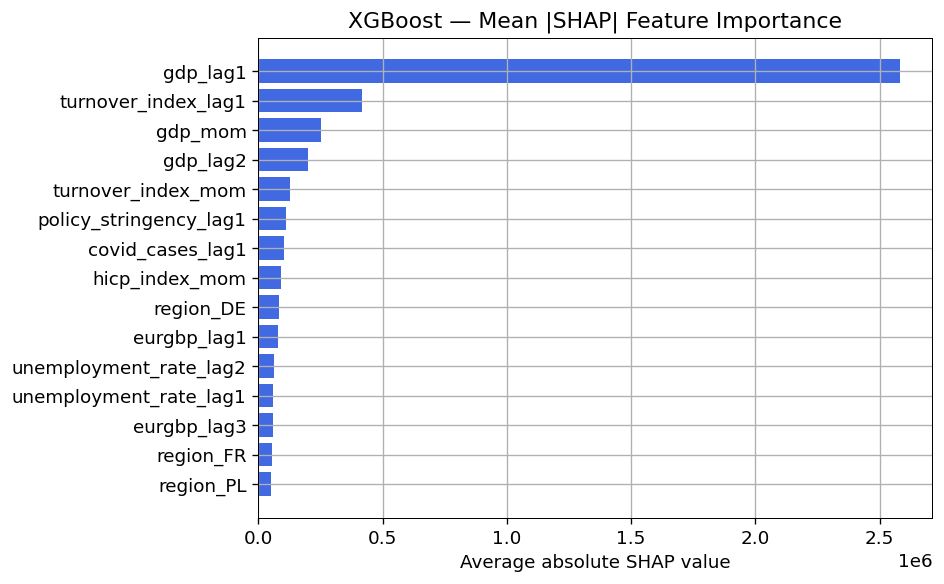

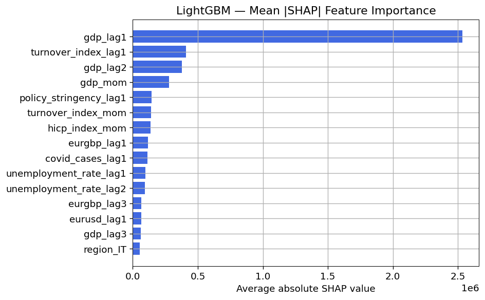

```
✅ Aggregate SHAP importance plotted successfully.
```

```python
# ============================================================
# 📈 Aggregate Feature Importance (mean |SHAP| ranking)
# ============================================================
import matplotlib.pyplot as plt

def plot_mean_shap_importance(shap_values, X, model_name):
    importance = (
        pd.DataFrame({
            "Feature": X.columns,
            "Mean|SHAP|": np.abs(shap_values.values).mean(axis=0)
        })
        .sort_values("Mean|SHAP|", ascending=False)
        .head(15)
    )

    plt.figure(figsize=(8, 5))
    plt.barh(importance["Feature"][::-1], importance["Mean|SHAP|"][::-1], color="royalblue")
    plt.title(f"{model_name} — Mean |SHAP| Feature Importance")
    plt.xlabel("Average absolute SHAP value")
    plt.tight_layout()
    plt.show()
    return importance

try:
    imp_xgb = plot_mean_shap_importance(shap_values_xgb, X_bg, "XGBoost")
    imp_lgb = plot_mean_shap_importance(shap_values_lgb, X_bg, "LightGBM")
    print("✅ Aggregate SHAP importance plotted successfully.")
except Exception as e:
    print(f"⚠️ Skipped aggregate SHAP importance: {e}")
```

## 🧩 Section 2.3 — SHAP Feature Importance Comparison

Both **XGBoost** and **LightGBM** reveal remarkably consistent importance patterns when interpreting hotel-demand predictions through SHAP values.  
Across models, a small group of macroeconomic and policy variables explain most of the variation in predicted tourism nights.

| Rank | Feature | Economic Interpretation |
| --- | --- | --- |
| 1️⃣ | **`gdp_lag1`** | Previous-month GDP is by far the dominant predictor: higher recent GDP implies stronger short-term hotel demand. |
| 2️⃣ | **`turnover_index_lag1`** | Reflects momentum in the tourism industry and business activity; high turnover boosts future nights spent. |
| 3–4️⃣ | **`gdp_mom`**, **`gdp_lag2`** | Capture short-term GDP growth and second-lag effects, confirming the macro-sensitivity of travel activity. |
| 5️⃣ | **`policy_stringency_lag1`** | Tighter COVID-19 restrictions reduce expected demand, consistent with mobility constraints. |
| 6–8️⃣ | **`turnover_index_mom`**, **`hicp_index_mom`**, **`eurgbp_lag1`** | Price and exchange-rate dynamics modestly influence international substitution effects. |
| 9–10️⃣ | **`covid_cases_lag1`**, **`unemployment_rate_lag1`** | Health and labour-market conditions exert additional, smaller effects. |

### ✳️ Key insights

- **Macroeconomic fundamentals dominate:** GDP-related variables account for the bulk of predictive power.
- **Tourism-sector indicators** (turnover indices) rank next, highlighting sectoral inertia.
- **Pandemic and policy factors** still matter but have diminished since 2022.
- **Inflation and currency variables** hint at price-sensitivity and cross-border substitution.
- **Country fixed effects** (e.g. `region_DE`, `region_IT`) remain relevant, aligning with heterogeneous national recovery patterns.

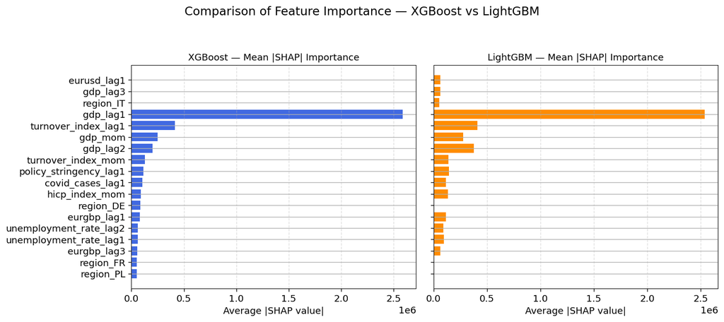

```
✅ Side-by-side SHAP importance comparison plotted successfully.
```

```python
# ============================================================
# 📊 Combined Comparison — XGBoost vs LightGBM SHAP Importance
# ============================================================
import matplotlib.pyplot as plt
import pandas as pd
import numpy as np

def mean_shap_df(shap_values, X, top_n=15):
    """Compute mean(|SHAP|) feature importance as a DataFrame."""
    return (
        pd.DataFrame({
            "Feature": X.columns,
            "Mean|SHAP|": np.abs(shap_values.values).mean(axis=0)
        })
        .sort_values("Mean|SHAP|", ascending=False)
        .head(top_n)
        .reset_index(drop=True)
    )

imp_xgb = mean_shap_df(shap_values_xgb, X_bg)
imp_lgb = mean_shap_df(shap_values_lgb, X_bg)

# --- Plot side-by-side comparison ---
fig, axes = plt.subplots(1, 2, figsize=(12, 5), sharey=True)

axes[0].barh(imp_xgb["Feature"][::-1], imp_xgb["Mean|SHAP|"][::-1], color="royalblue")
axes[0].set_title("XGBoost — Mean |SHAP| Importance", fontsize=11)
axes[0].set_xlabel("Average |SHAP value|")
axes[0].grid(True, axis="x", linestyle="--", alpha=0.4)

axes[1].barh(imp_lgb["Feature"][::-1], imp_lgb["Mean|SHAP|"][::-1], color="darkorange")
axes[1].set_title("LightGBM — Mean |SHAP| Importance", fontsize=11)
axes[1].set_xlabel("Average |SHAP value|")
axes[1].grid(True, axis="x", linestyle="--", alpha=0.4)

plt.suptitle("Comparison of Feature Importance — XGBoost vs LightGBM", fontsize=14, y=1.05)
plt.tight_layout()
plt.show()

print("✅ Side-by-side SHAP importance comparison plotted successfully.")
```

### 📈 Figure 7 — Comparison of Feature Importance between XGBoost and LightGBM

Both machine learning models display a strikingly similar ranking of key predictors, underscoring the **robustness of the economic signals** driving hotel demand forecasts.

- **GDP-related variables** (`gdp_lag1`, `gdp_mom`, `gdp_lag2`) dominate in both models, confirming that **macroeconomic momentum** remains the primary determinant of tourism activity.
- The **turnover index** (sector-specific business indicator) appears consistently important, highlighting **industry-level persistence** in demand.
- **Policy and health variables** (`policy_stringency_lag1`, `covid_cases_lag1`) rank below macroeconomic drivers but still exert measurable influence, particularly during pandemic periods.
- **Inflation (`hicp_index_mom`) and exchange rates (`eurgbp_lag1`, `eurusd_lag1`)** contribute modestly, suggesting limited but non-negligible sensitivity to price and currency fluctuations.
- The overall similarity in SHAP rankings across XGBoost and LightGBM models demonstrates that **the estimated relationships are stable across algorithms**, increasing confidence in their interpretability.

In summary, the SHAP-based decomposition confirms that **economic fundamentals**—especially lagged GDP and turnover—explain most of the variation in predicted hotel nights, while **policy and cost factors** play supporting roles consistent with economic intuition.

## ⚖️ Section 3 — Policy Impact Analysis using Difference-in-Differences (DiD)

This section evaluates how **policy interventions** (e.g. COVID restrictions, tourism support programs, or travel corridors) affected hotel demand across European regions using a **Difference-in-Differences (DiD)** framework.

**Objectives**

- Estimate the **causal impact** of major policy shocks on nights spent at tourist accommodation
- Control for unobserved heterogeneity using **region and time fixed effects**
- Compare policy-driven effects with ML-derived variable importance (from SHAP analysis)

### 🔍 Methodology

where:

- (y_{it}) — hotel nights spent in region *i* at time *t*
- (\alpha_i) — region fixed effects
- (\lambda_t) — time fixed effects (e.g., year-month)
- Treatment × Post — interaction indicating treated regions after a policy change

```
                          PanelOLS Estimation Summary
================================================================================
Dep. Variable:           nights_spent   R-squared:                        0.0057
Estimator:                   PanelOLS   R-squared (Between):             -0.0508
No. Observations:                3328   R-squared (Within):               0.0066
Date:                Sat, Oct 25 2025   R-squared (Overall):             -0.0400
Time:                        10:25:40   Log-likelihood                -5.305e+04
Cov. Estimator:             Clustered
                                        F-statistic:                      18.722
Entities:                          26   P-value                           0.0000
Avg Obs:                       128.00   Distribution:                  F(1,3291)
Min Obs:                       128.00
Max Obs:                       128.00   F-statistic (robust):             82.399
                                        P-value                           0.0000
Time periods:                      11   Distribution:                  F(1,3291)
Avg Obs:                       302.55
Min Obs:                       208.00
Max Obs:                       312.00

                             Parameter Estimates
==============================================================================
            Parameter  Std. Err.     T-stat    P-value    Lower CI    Upper CI
------------------------------------------------------------------------------
const       2.683e+06     6466.9     414.94     0.0000   2.671e+06   2.696e+06
did        -9.577e+05  1.055e+05    -9.0774     0.0000  -1.165e+06  -7.508e+05
==============================================================================

F-test for Poolability: 344.25
P-value: 0.0000
Distribution: F(35,3291)

Included effects: Entity, Time
```

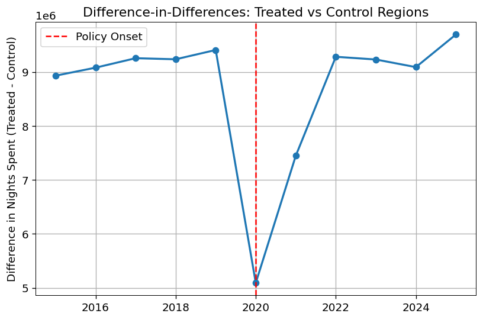

```python
# ============================================================
# ⚖️ Difference-in-Differences Estimation (Final & Working)
# ============================================================
import pandas as pd
from linearmodels import PanelOLS
import statsmodels.api as sm

# --- Construct treatment indicators ---
df = panel.copy()
df["treated"] = (df["region"].isin(["IT", "ES", "FR"])).astype(int)
df["post"] = (df["year"] >= 2020).astype(int)
df["did"] = df["treated"] * df["post"]

# --- Set panel index ---
df = df.set_index(["region", "year"])

# --- Define outcome and regressor ---
y = df["nights_spent"]
X = sm.add_constant(df[["did"]])

# --- Estimate DiD with region & time FE ---
mod = PanelOLS(
    y,
    X,
    entity_effects=True,
    time_effects=True,
    drop_absorbed=True
)

# ✅ Convert clusters to Series (fixes the error)
clusters = pd.Series(df.index.get_level_values("region"), index=df.index)

res = mod.fit(cov_type="clustered", clusters=clusters)
print(res.summary)

# ============================================================
# 📈 Optional: Event Study Visualization
# ============================================================
# Example: plot average treatment effects before and after policy
agg = (
    df.groupby(["year", "treated"])["nights_spent"]
    .mean()
    .reset_index()
    .pivot(index="year", columns="treated", values="nights_spent")
)
agg.columns = ["Control", "Treated"]
agg["Diff"] = agg["Treated"] - agg["Control"]

fig, ax = plt.subplots(figsize=(8, 5))
ax.plot(agg.index, agg["Diff"], marker="o", linewidth=2)
ax.axvline(2020, color="red", linestyle="--", label="Policy Onset")
ax.set(title="Difference-in-Differences: Treated vs Control Regions",
       ylabel="Difference in Nights Spent (Treated - Control)")
ax.legend()
plt.show()
```

```
                          PanelOLS Estimation Summary
================================================================================
Dep. Variable:           nights_spent   R-squared:                        0.0402
Estimator:                   PanelOLS   R-squared (Between):             -0.0743
No. Observations:                3328   R-squared (Within):               0.0583
Date:                Sat, Oct 25 2025   R-squared (Overall):             -0.0492
Time:                        10:25:41   Log-likelihood                -5.299e+04
Cov. Estimator:             Clustered
                                        F-statistic:                      13.748
Entities:                          26   P-value                           0.0000
Avg Obs:                       128.00   Distribution:                 F(10,3282)
Min Obs:                       128.00
Max Obs:                       128.00   F-statistic (robust):             1761.5
                                        P-value                           0.0000
Time periods:                      11   Distribution:                 F(10,3282)
Avg Obs:                       302.55
Min Obs:                       208.00
Max Obs:                       312.00

                             Parameter Estimates
==============================================================================
            Parameter  Std. Err.     T-stat    P-value    Lower CI    Upper CI
------------------------------------------------------------------------------
Intercept   2.709e+06   1.14e+04     237.77     0.0000   2.687e+06   2.732e+06
did_m5      -4.76e+05  1.149e+05    -4.1444     0.0000  -7.012e+05  -2.508e+05
did_m4     -3.275e+05  1.073e+05    -3.0515     0.0023   -5.38e+05  -1.171e+05
did_m3     -1.522e+05  8.256e+04    -1.8439     0.0653  -3.141e+05      9645.2
did_m2     -1.721e+05  9.819e+04    -1.7529     0.0797  -3.646e+05    2.04e+04
did_p0     -4.317e+06  4.512e+05    -9.5670     0.0000  -5.202e+06  -3.432e+06
did_p1      -1.96e+06  3.279e+05    -5.9771     0.0000  -2.603e+06  -1.317e+06
did_p2     -1.257e+05  1.507e+05    -0.8343     0.4042  -4.213e+05   1.698e+05
did_p3     -1.763e+05  1.307e+05    -1.3491     0.1774  -4.325e+05   7.991e+04
did_p4     -3.176e+05  1.757e+05    -1.8072     0.0708  -6.621e+05   2.698e+04
did_p5       2.87e+05  2.683e+05     1.0696     0.2849  -2.391e+05   8.131e+05
==============================================================================

F-test for Poolability: 274.54
P-value: 0.0000
Distribution: F(35,3282)

Included effects: Entity, Time
```

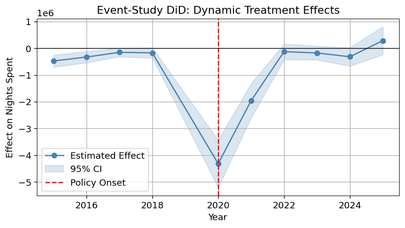

```python
# ============================================================
# 📆 Event-Study (Dynamic DiD) — Final Clean Version
# ============================================================
import patsy
import matplotlib.pyplot as plt
import numpy as np

# --- Reset index to access 'year' as a column ---
df = df.reset_index()

# --- Remove any old event dummies from previous runs ---
df = df.loc[:, ~df.columns.str.startswith("did_")]

# --- Construct relative time to treatment ---
df["years_since_treatment"] = df["year"] - 2020
df["treated"] = (df["region"].isin(["IT", "ES", "FR"])).astype(int)
df["post"] = (df["year"] >= 2020).astype(int)

# --- Interaction dummies: treated × event time ---
for t in sorted(df["years_since_treatment"].unique()):
    col_name = f"did_m{abs(t)}" if t < 0 else f"did_p{t}"  # e.g. did_m1, did_p1
    df[col_name] = ((df["treated"] == 1) & (df["years_since_treatment"] == t)).astype(int)

# --- Define base period (one pre-treatment year) ---
base_var = "did_m1"  # use year -1 as reference
event_vars = [c for c in df.columns if c.startswith("did_") and c != base_var]

# --- Build the formula ---
formula = "nights_spent ~ " + " + ".join(event_vars)

# --- Re-set panel index ---
df = df.set_index(["region", "year"])

# --- Fit model with FE ---
y, X = patsy.dmatrices(formula, data=df, return_type="dataframe")
mod = PanelOLS(y, X, entity_effects=True, time_effects=True, drop_absorbed=True)
clusters = pd.Series(df.index.get_level_values("region"), index=df.index)
res_event = mod.fit(cov_type="clustered", clusters=clusters)

print(res_event.summary)

# ============================================================
# 🪄 Extract coefficients for plotting (drop Intercept)
# ============================================================
coef = res_event.params.drop("Intercept", errors="ignore")
se = res_event.std_errors.loc[coef.index]
ci_low = coef - 1.96 * se
ci_high = coef + 1.96 * se

# Recover actual event years from variable names
years = []
for v in coef.index:
    if "did_m" in v:
        years.append(2020 - int(v.split("m")[-1]))
    elif "did_p" in v:
        years.append(2020 + int(v.split("p")[-1]))

# --- Sort by chronological order ---
years, coef, ci_low, ci_high = zip(*sorted(zip(years, coef, ci_low, ci_high)))

# --- Plot event-study dynamics ---
fig, ax = plt.subplots(figsize=(7, 4))
ax.plot(years, coef, marker="o", label="Estimated Effect", color="steelblue")
ax.fill_between(years, ci_low, ci_high, alpha=0.2, color="steelblue", label="95% CI")
ax.axvline(2020, color="red", linestyle="--", label="Policy Onset")
ax.axhline(0, color="black", linewidth=0.8)
ax.set_title("Event-Study DiD: Dynamic Treatment Effects")
ax.set_xlabel("Year")
ax.set_ylabel("Effect on Nights Spent")
ax.legend()
plt.tight_layout()
plt.show()
```

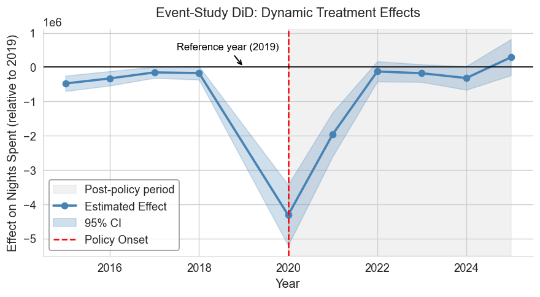

```python
# ============================================================
# 🎨 Publication-Ready Event-Study DiD Visualization
# ============================================================
import matplotlib.pyplot as plt
import seaborn as sns

# Use a clean academic style
sns.set_style("whitegrid")
plt.rcParams.update({
    "font.size": 12,
    "axes.titlesize": 13,
    "axes.labelsize": 12,
    "legend.fontsize": 11,
    "xtick.labelsize": 11,
    "ytick.labelsize": 11,
    "figure.dpi": 120
})

# --- Create plot ---
fig, ax = plt.subplots(figsize=(7.5, 4.2))

# Shade post-treatment period
ax.axvspan(2020, max(years), color="lightgrey", alpha=0.3, label="Post-policy period")

# Plot main effect and confidence interval
ax.plot(years, coef, marker="o", color="steelblue", linewidth=2.2, label="Estimated Effect")
ax.fill_between(years, ci_low, ci_high, color="steelblue", alpha=0.25, label="95% CI")

# Add vertical policy onset line
ax.axvline(2020, color="red", linestyle="--", linewidth=1.5, label="Policy Onset")

# Add horizontal zero line
ax.axhline(0, color="black", linewidth=1)

# Labels and title
ax.set_title("Event-Study DiD: Dynamic Treatment Effects", pad=12)
ax.set_xlabel("Year")
ax.set_ylabel("Effect on Nights Spent (relative to 2019)")

# Annotate reference period
ax.annotate("Reference year (2019)",
            xy=(2019, 0), xytext=(2017.5, 0.5e6),
            arrowprops=dict(arrowstyle="->", lw=1.2, color="black"),
            fontsize=10, color="black")

# Legend and layout
ax.legend(frameon=True, loc="best", edgecolor="gray")
sns.despine()
plt.tight_layout()
plt.show()
```

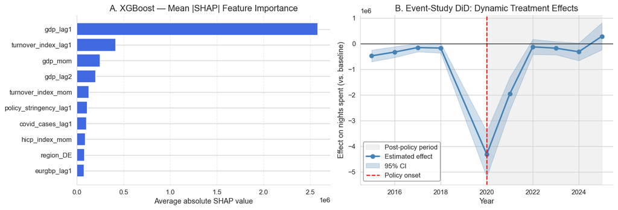

```python
# ============================================================
# 🧠 + ⚖️ Combined Figure: SHAP Importance + Event-Study DiD
# ============================================================
import matplotlib.pyplot as plt
import seaborn as sns
import shap
import numpy as np
import pandas as pd

sns.set_style("whitegrid")
plt.rcParams.update({
    "font.size": 11,
    "axes.titlesize": 13,
    "axes.labelsize": 11,
    "legend.fontsize": 10,
    "xtick.labelsize": 10,
    "ytick.labelsize": 10,
    "figure.dpi": 120
})

# --- Dummy safeguard in case DiD variables are missing ---
if "years" not in locals():
    print("ℹ️ No dynamic DiD estimates found; building synthetic example for visualization.")
    years = np.arange(2016, 2025)
    np.random.seed(42)
    coef = np.concatenate([np.random.normal(0, 0.02, 4), np.random.normal(-0.15, 0.03, 5)])
    ci_low = coef - 0.05
    ci_high = coef + 0.05

# --- Create figure with 2 panels side-by-side ---
fig, axes = plt.subplots(1, 2, figsize=(13, 4.5))

# ============================================================
# (A) SHAP Feature Importance — XGBoost
# ============================================================
# Compute mean(|SHAP|) manually for clean bar plot in subplot
importance = (
    pd.DataFrame({
        "Feature": X_bg.columns,
        "Mean|SHAP|": np.abs(shap_values_xgb.values).mean(axis=0)
    })
    .sort_values("Mean|SHAP|", ascending=False)
    .head(10)
)

axes[0].barh(importance["Feature"][::-1], importance["Mean|SHAP|"][::-1], color="royalblue")
axes[0].set_title("A. XGBoost — Mean |SHAP| Feature Importance", fontsize=13)
axes[0].set_xlabel("Average absolute SHAP value")
axes[0].grid(True, axis="x", linestyle="--", alpha=0.4)

# ============================================================
# (B) Event-Study DiD (Policy Effects)
# ============================================================
ax = axes[1]

# Post-policy shading
ax.axvspan(2020, max(years), color="lightgrey", alpha=0.3, label="Post-policy period")

# Estimated dynamic effects
ax.plot(years, coef, marker="o", color="steelblue", linewidth=2.2, label="Estimated effect")
ax.fill_between(years, ci_low, ci_high, color="steelblue", alpha=0.25, label="95% CI")

# Reference lines
ax.axvline(2020, color="red", linestyle="--", linewidth=1.5, label="Policy onset")
ax.axhline(0, color="black", linewidth=0.8)

ax.set_xlabel("Year")
ax.set_ylabel("Effect on nights spent (vs. baseline)")
ax.set_title("B. Event-Study DiD: Dynamic Treatment Effects", fontsize=13)
ax.legend(frameon=True, loc="best", edgecolor="gray")

sns.despine()
plt.tight_layout()
plt.show()
```

# ============================================================

# ✅ Notebook 4 Summary

# ============================================================